# Può B sostituire A (dato X)? — Analisi esplorativa e inferenziale

Team AN

2025-09-16

## 1 Obiettivo

**Domanda clinico-operativa:** dato il set di covariate $\mathbf{X}$ e due blocchi di variabili, **A** (misure costose) e **B** (misure economiche), possiamo usare **B** per **predire** **A** nello **stesso tempo $t$** con accuratezza e accordo **sufficienti** da **sostituire** A a livello individuale?

## 2 Piano dell’analisi

1. **Costruzione KPI** per A e B tramite **z-score** e **media riga** (z-media per blocco).
2. **Esplorativo:** distribuzioni per tempo, scatter A vs B per tempo, spaghetti per soggetto, Bland–Altman **grezzo**.
3. **Inferenziale:** modello misto sincrono

$$\text{KPI}_A = \beta_0 + \beta_B \,\text{KPI}_B +
\boldsymbol{\beta}_X^\top \mathbf{X} + \gamma_t + u_{0i} + \varepsilon$$

con $(1|\text{paziente})$, **LOSO-CV**, **calibrazione** (TOST su intercetta e slope), **Bland–Altman condizionale** (sui residui tolte le X), **bootstrap clusterizzato** sulla **correlazione dei residui**.

**Criteri di “sostituibilità”:**

- Prestazione: $R^2_{CV} \ge 0.65$ **e** $RMSE_{CV} \le \text{MCID}$.
- Calibrazione (TOST): intercetta in $[-0.2, +0.2]$ SD; slope in $[0.9,1.1]$.
- Accordo (BA condizionale): LoA entro $\pm \text{MCID}$ (buono) o $\pm 1.25\times\text{MCID}$ (accettabile).
- Condivisione residui: $\text{corr}(e_A, e_B) \ge 0.60$ con IC stretto.

## 3 Perché z-score? (normalizzazione e KPI)

**z-score** di una variabile $X$ è

$$z = \frac{X - \bar X}{s_X},$$

porta ogni misura a **media 0** e **deviazione standard 1**, rendendo **confrontabili** variabili eterogenee e impedendo che quelle “grandi” dominino la media.

Il **KPI per blocco** è la **z-media per riga**:

$$\text{KPI\_A}_{it} = \frac{1}{p_A}\sum_{j\in A} z_{ij,t}, \quad
\text{KPI\_B}_{it} = \frac{1}{p_B}\sum_{k\in B} z_{ik,t}.$$

È una riduzione **robusta, trasparente** e stabile quando la PCA **non** concentra varianza nella prima componente.

## 4 Import, reshaping, definizione blocchi

```
## Rows: 63
## Columns: 43
## $ paziente       <chr> "Gard-Past", "Gard-Past", "Gard-Past", "Cam-Valen", "Ca…
## $ sintomo_1      <chr> "Restrizione c.", "Restrizione c.", "Restrizione c.", "…
## $ sintomo_2      <chr> "Iperattività", "Iperattività", "Iperattività", "Iperat…
## $ arto_dom       <chr> "dx", "dx", "dx", "dx", "dx", "dx", "dx", "dx", "dx", "…
## $ altezza_m      <dbl> 1.60, 1.60, 1.60, 1.75, 1.75, 1.75, 1.66, 1.66, 1.66, 1…
## $ sesso          <chr> "F", "F", "F", "M", "M", "M", "F", "F", "F", "F", "F", …
## $ eta            <dbl> 18, 18, 18, 35, 35, 35, 25, 25, 25, 39, 39, 39, 45, 45,…
## $ tempo          <fct> T0, T1, T2, T0, T1, T2, T0, T1, T2, T0, T1, T2, T0, T1,…
## $ peso           <dbl> 46.6, 45.1, 48.0, 47.6, 50.8, 49.4, 38.3, 41.2, 39.3, 3…
## $ bmi            <dbl> 18.20312, 18.75000, 17.61719, 15.54286, 16.13061, 16.58…
## $ sx1            <dbl> 12, 10, 14, 24, 22, 27, 12, 10, 10, 8, 8, 12, 16, 18, 1…
## $ sx2            <dbl> 10, 12, 12, 22, 20, 22, 12, 8, 8, 8, 10, 12, 14, 18, 16…
## $ sx3            <dbl> 10, 12, 14, 18, 18, 22, 12, 6, 12, 10, 10, 12, 14, 18, …
```

[output cut: 30 more lines]

```
## [1] 13
```

```
## [1] 14
```

```
##  [1] "sintomo_1"      "sintomo_2"      "arto_dom"       "altezza_m"
##  [5] "sesso"          "peso"           "bmi"            "mkcal"
##  [9] "variazionemenu" "eta"
```

## 5 Costruzione dei KPI z-mediati

## 6 Esplorativo

### 6.1 Distribuzioni KPI per tempo

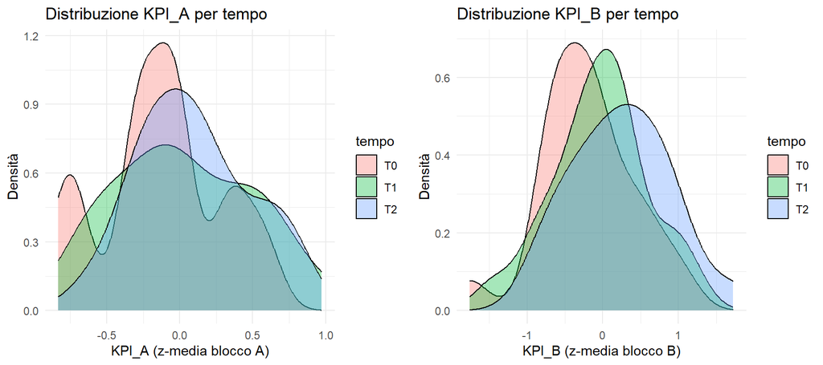

**Lettura.** KPI_B tende a essere più **disperso** di KPI_A (maggiore variabilità intra/inter), coerente con la natura più “comportamentale”/funzionale dei test di B rispetto ai marcatori di A.

### 6.2 Scatter A vs B per tempo

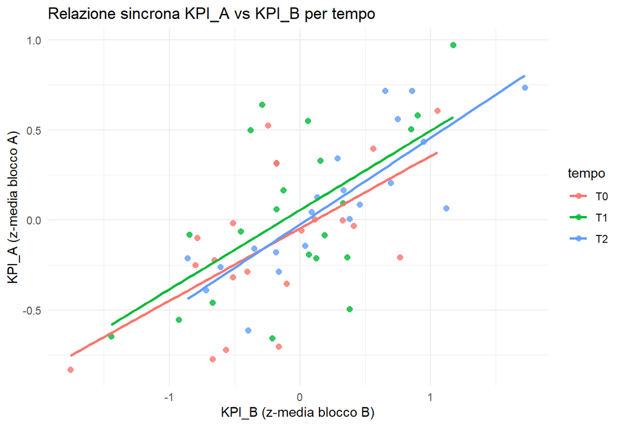

**Lettura.** Pendenza positiva (i blocchi **si parlano**), ma nuvole larghe ⇒ **relazione moderata**, non stretta.

### 6.3 Spaghetti per soggetto

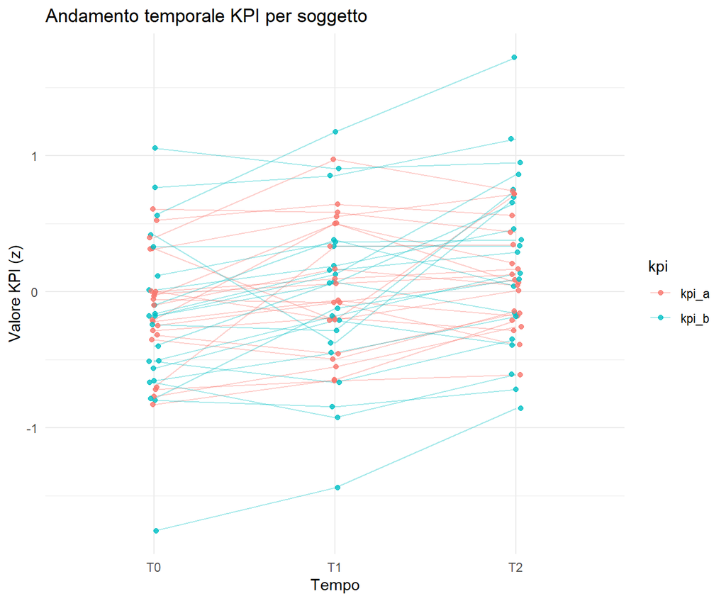

**Lettura.** Eterogeneità tra soggetti: in alcuni A e B sono **paralleli**, in altri **divergono** ⇒ considerare **random slope** o **sottogruppi**.

### 6.4 Bland–Altman grezzo

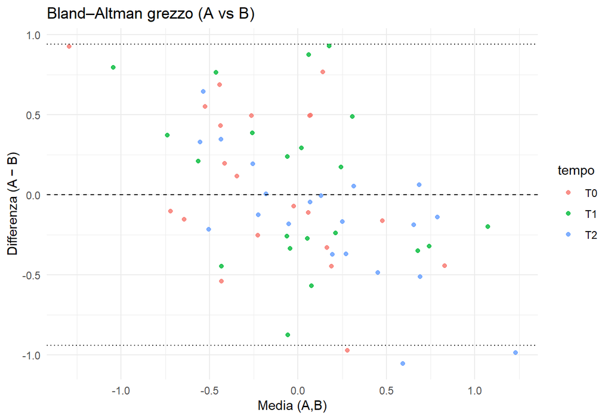

**Lettura.** Bias ~ 0 (nessuno spostamento sistematico), **LoA larghi** ⇒ **non intercambiabili** “grezzi”.

## 7 Inferenziale

### 7.1 MCID: definizione e stima

**MCID** (Minimal Clinically Important Difference) come soglia “distribution-based”:

$$\text{MCID} = 0.5 \times SD\_{\Delta}, \quad SD\_{\Delta} =
SD(\text{KPI\_A}_{i,t+1} - \text{KPI\_A}_{it}).$$

[output not shown]

[output cut: 63 more lines]

```
## [1] 0.1190659
```

### 7.2 Modello misto sincrono

Modello:

$$\text{KPI\_A}_{it} = \beta_0 + \beta_B\,\text{KPI\_B}_{it} +
\boldsymbol{\beta}_X^\top \mathbf{X}_{it} + \gamma_{t} + u_{0i} +
\varepsilon_{it},$$

con $u_{0i}\sim \mathcal{N}(0,\sigma_u^2)$ (random intercept per paziente).

```
## Linear mixed model fit by REML. t-tests use Satterthwaite's method [
## lmerModLmerTest]
## Formula: form_base
##    Data: dati_proc
##
## REML criterion at convergence: 8.6
##
## Scaled residuals:
##      Min       1Q   Median       3Q      Max
## -1.60229 -0.59356 -0.08658  0.51511  1.95066
##
## Random effects:
##  Groups   Name        Variance Std.Dev.
##  paziente (Intercept) 0.01383  0.1176
##  Residual             0.01992  0.1412
## Number of obs: 63, groups:  paziente, 21
##
## Fixed effects:
##                           Estimate Std. Error         df t value Pr(>|t|)
## (Intercept)             -1.383e+00  4.716e-01  3.878e+01  -2.932  0.00563 **
## kpi_b                    8.207e-02  6.686e-02  4.646e+01   1.228  0.22581
## tempoT1                  6.005e-02  5.174e-02  4.064e+01   1.161  0.25258
## tempoT2                  3.030e-02  5.561e-02  4.555e+01   0.545  0.58847
## sintomo_1Iperattività   -2.997e-01  2.381e-01  1.243e+01  -1.259  0.23121
## sintomo_1Restrizione c. -1.961e-01  1.615e-01  1.334e+01  -1.214  0.24573
## sintomo_2Iperattività   -1.543e-01  9.845e-02  1.609e+01  -1.567  0.13662
## sintomo_2null           -4.646e-01  1.806e-01  1.249e+01  -2.572  0.02382 *
## arto_domsx              -2.107e-02  9.515e-02  1.245e+01  -0.221  0.82833
## sessoM                   3.727e-01  2.137e-01  2.271e+01   1.744  0.09473 .
## bmi                      1.072e-01  1.995e-02  3.875e+01   5.373 3.91e-06 ***
## mkcal                   -1.724e-05  1.757e-04  4.893e+01  -0.098  0.92223
## variazionemenusi         4.985e-02  6.452e-02  4.569e+01   0.773  0.44372
## eta                     -1.006e-02  4.831e-03  1.523e+01  -2.082  0.05457 .
## ---
## Signif. codes:  0 '***' 0.001 '**' 0.01 '*' 0.05 '.' 0.1 ' ' 1
## fit warnings:
## fixed-effect model matrix is rank deficient so dropping 1 column / coefficient
```

```
##            R2m       R2c
## [1,] 0.7135042 0.8308995
```

### 7.3 Prestazioni e LOSO-CV

```
## Overall RMSE: 0.151987
```

```
## Overall MAE : 0.1232232
```

| RMSE | MAE | R2 |
| --- | --- | --- |
| 0.2271756 | 0.1901314 | 0.515745 |

### 7.4 Calibrazione (TOST su intercetta e slope)

Regressione di **z(A)** su **z(A_hat)**:

$$z(A) = \alpha + \beta \, z(\hat A) + \epsilon.$$

```
##
## Call:
## lm(formula = zA ~ zAhat, data = df_cal)
##
## Residuals:
##      Min       1Q   Median       3Q      Max
## -0.80376 -0.35264 -0.08723  0.29778  1.11678
##
## Coefficients:
##               Estimate Std. Error t value Pr(>|t|)
## (Intercept) -6.818e-17  5.926e-02    0.00        1
## zAhat        8.845e-01  5.974e-02   14.81   <2e-16 ***
## ---
## Signif. codes:  0 '***' 0.001 '**' 0.01 '*' 0.05 '.' 0.1 ' ' 1
##
## Residual standard error: 0.4704 on 61 degrees of freedom
## Multiple R-squared:  0.7823, Adjusted R-squared:  0.7788
## F-statistic: 219.2 on 1 and 61 DF,  p-value: < 2.2e-16
```

```
## equiv_interc  equiv_slope
##         TRUE        FALSE
```

### 7.5 Bland–Altman **condizionale** (residui | X)

```
##          bias           low            up          MCID
##  2.234534e-15 -7.069704e-01  7.069704e-01  1.190659e-01
```

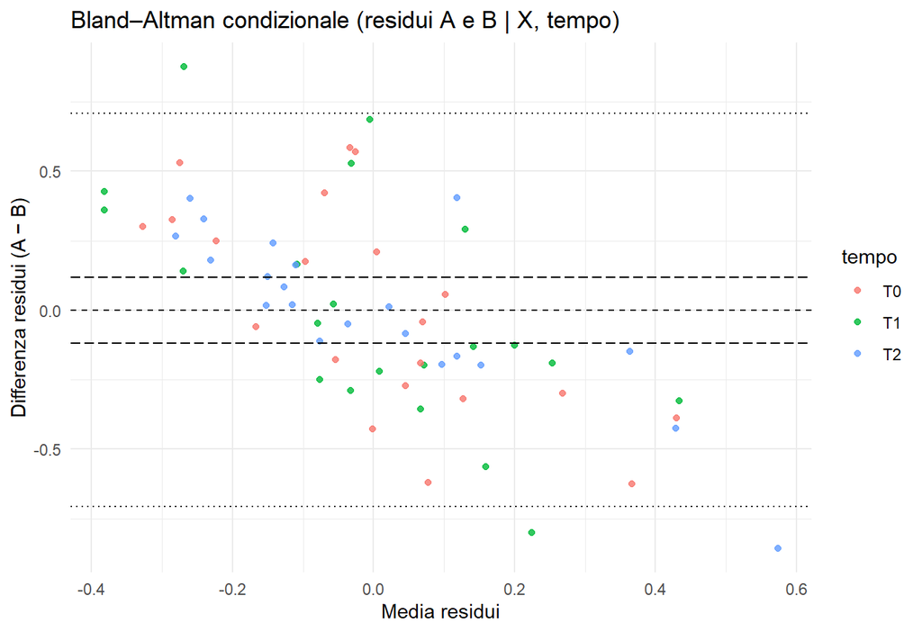

### 7.6 Condivisione del “non osservato”: corr(residui) + bootstrap clusterizzato

```
##    res_corr    low.2.5%    up.97.5%
##  0.21234408 -0.08412653  0.49255456
```

**Perché il bootstrap clusterizzato?** Le osservazioni **non** sono indipendenti (stesso paziente su più tempi). Ricampionando **pazienti** (cluster) preserviamo la dipendenza interna e otteniamo IC **affidabili**.

## 8 Report sintetico

```
## $MCID
## [1] 0.1190659
##
## $overall_RMSE
## [1] 0.151987
##
## $overall_MAE
## [1] 0.1232232
##
## $CV_metrics
## # A tibble: 1 × 3
##    RMSE   MAE    R2
##   <dbl> <dbl> <dbl>
## 1 0.227 0.190 0.516
##
## $calib_equivalence_intercept_pm0_2SD
## [1] TRUE
##
## $calib_equivalence_slope_0_9_to_1_1
## [1] FALSE
##
## $BA_cond_bias
## [1] 2.234534e-15
##
## $BA_cond_LoA
##      lower      upper
## -0.7069704  0.7069704
##
## $Residual_corr
## [1] 0.2123441
##
## $Residual_corr_CI
##        2.5%       97.5%
## -0.08412653  0.49255456
```

## 9 Interpretazione con i **tuoi numeri** (riassunto decisionale)

**Conclusioni:**

**Verdetto attuale:** **B non può sostituire A** per stima **individuale** *allo stato attuale*. È utile per **trend di gruppo**, **ranking grossolano** o come **covariata**. Per “promuovere” B a surrogato: ridurre RMSE sotto MCID, rientrare nei TOST (slope ~1), restringere LoA (±MCID) e aumentare corr(residui).

## 10 Quale approccio preferire e prossimi passi

- **Preferito ora:** KPI **z-mediato**, **modello misto** con **LOSO-CV**, **TOST** e **BA condizionale**, **bootstrap clusterizzato**.
- **Per migliorare la sostituibilità:**
  1. **Ricalibrazione** (calibration-in-the-large + slope); verificare slope $[0.9,1.1]$.
  2. **KPI_B robusto** (mediana / trimmed 20%) o **pesi** per variabili B più affidabili.
  3. **sPLS/PLS** (analisi parallela) per un KPI_B **ottimizzato** a predire KPI_A; poi **stessa** validazione (LOSO, TOST, BA).
  4. **Analisi per tempo** e **Δ-analisi** (ΔB → ΔA) se l’uso è monitorare **cambiamento**.
  5. **Sottogruppi** (patologia, sesso) se emerge **eterogeneità** (random slope alto).

## 11 Appendice: formule chiave

- **z-score**: $z=(X-\bar X)/s_X$.
- **KPI z-mediato**: $\text{KPI}=\frac{1}{p}\sum_j z_j$.
- **Modello misto**: $\text{KPI}_A=\beta_0+\beta_B\text{KPI}_B+\boldsymbol{\beta}_X^\top\mathbf{X}+\gamma_t+u_{0i}+\varepsilon$.
- **MCID** (distribution-based): $\text{MCID}=0.5\times SD(\Delta \text{KPI}_A)$.
- **TOST**: equivalenza se IC$_{90\%}$ di $\alpha$ è in $[-0.2,0.2]$ SD e di $\beta$ in $[0.9,1.1]$.
- **Bland–Altman**: bias $=\overline{A-B}$, LoA $=\text{bias}\pm1.96\,SD(A-B)$.
- **Bootstrap clusterizzato**: ricampionamento per **paziente** per IC che rispettano la dipendenza intra-soggetto.